# FittingSouthScania

```python
%matplotlib notebook
```

%matplotlib notebook

```python
%load_ext autoreload
%autoreload 3
```

%load_ext autoreload %autoreload 3

```
The autoreload extension is already loaded. To reload it, use:
  %reload_ext autoreload
```

```python
import sys
import os

IN_COLAB = 'google.colab' in sys.modules

main_dir = '/content/PythonMathematicalModeling/' if IN_COLAB else ''
docs_dir = os.path.join(main_dir, 'docs')
project_dir = os.path.join(docs_dir, 'PlagueProject') if IN_COLAB else ''
data_private_folder = os.path.join(project_dir, 'data', 'private')

# GitHub credentials for Colab

USERNAME="" # Your GitHub username
GH_TOKEN="" # Your github token (Settings -> Developer Settings -> Personal Access Tokens -> Generate new token)

if IN_COLAB:
  ! rm -rf *
  ! git config --system credential.helper store
  ! echo "https://{USERNAME}:{GH_TOKEN}@github.com" > ~/.git-credentials
  ! git clone --recurse-submodules https://github.com/polislizarralde/PythonMathematicalModeling
  sys.path += [main_dir, docs_dir, project_dir, data_private_folder]
```

import sys import os IN_COLAB = 'google.colab' in sys.modules main_dir = '/content/PythonMathematicalModeling/' if IN_COLAB else '' docs_dir = os.path.join(main_dir, 'docs') project_dir = os.path.join(docs_dir, 'PlagueProject') if IN_COLAB else '' data_private_folder = os.path.join(project_dir, 'data', 'private') # GitHub credentials for Colab USERNAME="" # Your GitHub username GH_TOKEN="" # Your github token (Settings -> Developer Settings -> Personal Access Tokens -> Generate new token) if IN_COLAB: ! rm -rf * ! git config --system credential.helper store ! echo "https://{USERNAME}:{GH_TOKEN}@github.com" > ~/.git-credentials ! git clone --recurse-submodules https://github.com/polislizarralde/PythonMathematicalModeling sys.path += [main_dir, docs_dir, project_dir, data_private_folder]

```python
try:
  from funct_process_data import *  # Import all functions from funct_process_data.py
except ImportError:
  if IN_COLAB:
    ! pip3 install -r PythonMathematicalModeling/requirements.txt
    print('Stopping RUNTIME! Please run again.')
    os.kill(os.getpid(), 9)
```

try: from funct_process_data import * # Import all functions from funct_process_data.py except ImportError: if IN_COLAB: ! pip3 install -r PythonMathematicalModeling/requirements.txt print('Stopping RUNTIME! Please run again.') os.kill(os.getpid(), 9)

```python
%matplotlib inline
```

%matplotlib inline

```python
# Get the current working directory
data_folder = "MapScaniaSweden"
SkaneMap_path = os.path.join(data_folder, "Skane1720_1890.shp")

SkaneMap = gpd.read_file(SkaneMap_path)
selected_columns = ['G_NAME', 'GET_END_YE', 'geometry']
SkaneMap = SkaneMap[selected_columns]
```

# Get the current working directory data_folder = "MapScaniaSweden" SkaneMap_path = os.path.join(data_folder, "Skane1720_1890.shp") SkaneMap = gpd.read_file(SkaneMap_path) selected_columns = ['G_NAME', 'GET_END_YE', 'geometry'] SkaneMap = SkaneMap[selected_columns]

```python
# Set the working directory for private files

# Southeast Scania
southeast_path = os.path.join(data_private_folder, 'southeastScania.csv')
southeastScania = pd.read_csv(southeast_path, sep=',')
# Middle Scania
middle_path = os.path.join(data_private_folder, 'middleScania.csv')
middleScania = pd.read_csv(middle_path, sep=',')
# Southwest Scania
southwest_path = os.path.join(data_private_folder, 'southwestScania.csv')
southwestScania = pd.read_csv(southwest_path, sep=',')

# Concatenate all the South Scania data into one dataframe and reset the index
southScania = pd.concat([southeastScania, middleScania, southwestScania], ignore_index=True)
```

# Set the working directory for private files # Southeast Scania southeast_path = os.path.join(data_private_folder, 'southeastScania.csv') southeastScania = pd.read_csv(southeast_path, sep=',') # Middle Scania middle_path = os.path.join(data_private_folder, 'middleScania.csv') middleScania = pd.read_csv(middle_path, sep=',') # Southwest Scania southwest_path = os.path.join(data_private_folder, 'southwestScania.csv') southwestScania = pd.read_csv(southwest_path, sep=',') # Concatenate all the South Scania data into one dataframe and reset the index southScania = pd.concat([southeastScania, middleScania, southwestScania], ignore_index=True)

```python
# Convert WKT (Well-Known Text) geometry to Shapely geometry
southScania['geometry'] = southScania['geometry'].apply(wkt.loads)
# Create a GeoDataFrame from the DataFrame
southScaniaMap = gpd.GeoDataFrame(southScania, geometry='geometry')
```

# Convert WKT (Well-Known Text) geometry to Shapely geometry southScania['geometry'] = southScania['geometry'].apply(wkt.loads) # Create a GeoDataFrame from the DataFrame southScaniaMap = gpd.GeoDataFrame(southScania, geometry='geometry')

Plotting the parishes from South Scania

```python
# Assigning the coordinate reference system (CRS) to the GeoDataFrame
southScaniaMap = southScaniaMap.set_crs("EPSG:3034")

# For checking the CRS
# southScaniaMap.crs
```

# Assigning the coordinate reference system (CRS) to the GeoDataFrame southScaniaMap = southScaniaMap.set_crs("EPSG:3034") # For checking the CRS # southScaniaMap.crs

```python
colorByColumn(southScaniaMap, 'EndPlaguePeriod')
southMap : folium.folium.Map = SkaneMap.explore(
    column="G_NAME",
    style_kwds=dict(color="black"),  # use black for borders
    tooltip=False,
    zoom_control=False,
    legend=False,
    #scheme="naturalbreaks",  # use mapclassify's natural breaks scheme
    legend_kwds=dict(colorbar=False),  # do not use colorbar
    name="Scania",  # name of the layer in the map
)

southScaniaMap.explore(
    m = southMap,  # pass the map object
    column="color",  # use "name" column to assign colors
    cmap=['blue','red'],  # color map to use
    legend=False,  # show legend
    style_kwds=dict(color="black"),  # use black for borders
    marker_kwds=dict(radius=5, fill=True),  # make marker radius 10px with fill
    # show "name" column in the tooltip
    tooltip=["G_NAME", "BEF1699", "BeginPlaguePeriod", "EndPlaguePeriod", "VictimsNumber"],
    tooltip_kwds=dict(labels=True),  # show column label in the tooltip
    name="South Scania",  # name of the layer in the map,
    zoom_control=False,
)

folium.TileLayer("Stamen Toner", show=False).add_to(
    southMap
)  # use folium to add alternative tiles
folium.LayerControl().add_to(southMap)  # use folium to add layer control

southMap  # show map
```

colorByColumn(southScaniaMap, 'EndPlaguePeriod') southMap : folium.folium.Map = SkaneMap.explore( column="G_NAME", style_kwds=dict(color="black"), # use black for borders tooltip=False, zoom_control=False, legend=False, #scheme="naturalbreaks", # use mapclassify's natural breaks scheme legend_kwds=dict(colorbar=False), # do not use colorbar name="Scania", # name of the layer in the map ) southScaniaMap.explore( m = southMap, # pass the map object column="color", # use "name" column to assign colors cmap=['blue','red'], # color map to use legend=False, # show legend style_kwds=dict(color="black"), # use black for borders marker_kwds=dict(radius=5, fill=True), # make marker radius 10px with fill # show "name" column in the tooltip tooltip=["G_NAME", "BEF1699", "BeginPlaguePeriod", "EndPlaguePeriod", "VictimsNumber"], tooltip_kwds=dict(labels=True), # show column label in the tooltip name="South Scania", # name of the layer in the map, zoom_control=False, ) folium.TileLayer("Stamen Toner", show=False).add_to( southMap ) # use folium to add alternative tiles folium.LayerControl().add_to(southMap) # use folium to add layer control southMap # show map

Make this Notebook Trusted to load map: File -> Trust Notebook

[interactive chart not shown]

```python
colorByColumn(southScaniaMap, 'EndPlaguePeriod')
fig, ax = plt.subplots(figsize=(10, 7))
SkaneMap.plot(ax=ax, column="G_NAME", edgecolor='black',
              legend=False, cmap='Pastel2')
southScaniaMap.plot(ax=ax, column="color", cmap='Reds',
                        edgecolor='black', legend=False)
plt.xlabel('Meters')
plt.ylabel('Meters')
plt.show()
```

colorByColumn(southScaniaMap, 'EndPlaguePeriod') fig, ax = plt.subplots(figsize=(10, 7)) SkaneMap.plot(ax=ax, column="G_NAME", edgecolor='black', legend=False, cmap='Pastel2') southScaniaMap.plot(ax=ax, column="color", cmap='Reds', edgecolor='black', legend=False) plt.xlabel('Meters') plt.ylabel('Meters') plt.show()

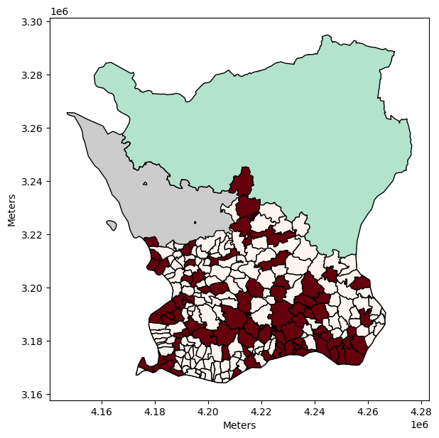

We will focus only in the parishes affected by the plague. To do so, first we filter the data frame.

```python
plagueSouthScania = southScaniaMap[southScaniaMap['color'] == 'red']
len(plagueSouthScania)


fig, ax = plt.subplots(figsize=(10, 7))
SkaneMap.plot(ax=ax, color = 'lightgray', edgecolor='black',
              legend=False)
plagueSouthScania.plot(ax=ax, color = 'darkred',
                        edgecolor='black', legend=False)
plt.xlabel('Meters')
plt.ylabel('Meters')
plt.show()
```

plagueSouthScania = southScaniaMap[southScaniaMap['color'] == 'red'] len(plagueSouthScania) fig, ax = plt.subplots(figsize=(10, 7)) SkaneMap.plot(ax=ax, color = 'lightgray', edgecolor='black', legend=False) plagueSouthScania.plot(ax=ax, color = 'darkred', edgecolor='black', legend=False) plt.xlabel('Meters') plt.ylabel('Meters') plt.show()

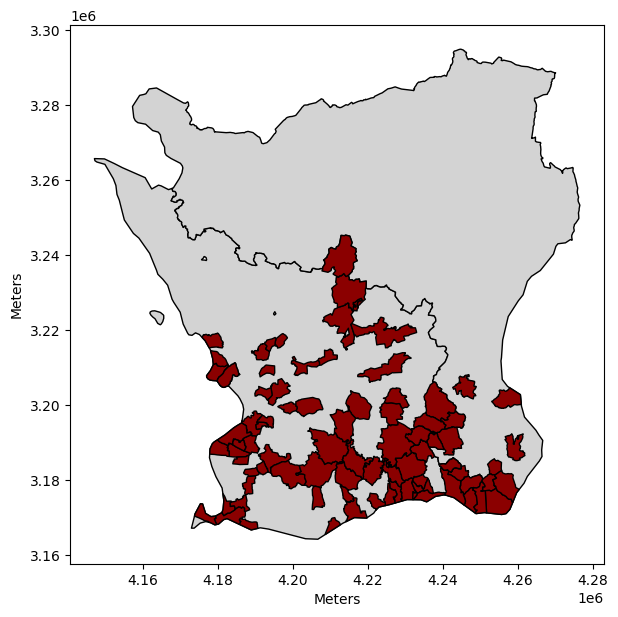

```python
# replaced all the occurences of 'UNDEFINED' and '?' with np.nan in our dataframe
plagueSouthScania = plagueSouthScania.replace(['UNDEFINED', '?'], np.nan)
```

# replaced all the occurences of 'UNDEFINED' and '?' with np.nan in our dataframe plagueSouthScania = plagueSouthScania.replace(['UNDEFINED', '?'], np.nan)

```python
plagueSouthScania['BeginPlaguePeriod'] = pd.to_datetime(
    plagueSouthScania['BeginPlaguePeriod'], format='%b %Y')
plagueSouthScania['EndPlaguePeriod'] = pd.to_datetime(
    plagueSouthScania['EndPlaguePeriod'], format='%b %Y')
plagueSouthScania.sort_values(
    by=['BeginPlaguePeriod'],   # Row or columns names to sort by
    axis=0,       # Sort Rows axis = 0
    ascending=True,  # Sort ascending or descending?
    # Modify the DataFrame in place (do not create a new object)
    inplace=True
)

plagueSouthScania.reset_index(drop=True, inplace=True)
```

plagueSouthScania['BeginPlaguePeriod'] = pd.to_datetime( plagueSouthScania['BeginPlaguePeriod'], format='%b %Y') plagueSouthScania['EndPlaguePeriod'] = pd.to_datetime( plagueSouthScania['EndPlaguePeriod'], format='%b %Y') plagueSouthScania.sort_values( by=['BeginPlaguePeriod'], # Row or columns names to sort by axis=0, # Sort Rows axis = 0 ascending=True, # Sort ascending or descending? # Modify the DataFrame in place (do not create a new object) inplace=True ) plagueSouthScania.reset_index(drop=True, inplace=True)

```python
# Create a new column called "BeginDaysPlague"
plagueSouthScania["BeginDaysPlague"] = plagueSouthScania.apply(
    # axis = 1 means apply function to each row
    lambda row: begin_days_between(plagueSouthScania["BeginPlaguePeriod"].iloc[0], row["BeginPlaguePeriod"]), axis=1
)

# Create a new column called "EndDaysPlague"
plagueSouthScania['EndDaysPlague'] = plagueSouthScania.apply(lambda row: end_days_between(
    plagueSouthScania['BeginPlaguePeriod'].iloc[0], row['EndPlaguePeriod']) if pd.notna(row['EndPlaguePeriod']) else None, axis=1)
```

# Create a new column called "BeginDaysPlague" plagueSouthScania["BeginDaysPlague"] = plagueSouthScania.apply( # axis = 1 means apply function to each row lambda row: begin_days_between(plagueSouthScania["BeginPlaguePeriod"].iloc[0], row["BeginPlaguePeriod"]), axis=1 ) # Create a new column called "EndDaysPlague" plagueSouthScania['EndDaysPlague'] = plagueSouthScania.apply(lambda row: end_days_between( plagueSouthScania['BeginPlaguePeriod'].iloc[0], row['EndPlaguePeriod']) if pd.notna(row['EndPlaguePeriod']) else None, axis=1)

```python
# Replace NaN values with a value in some columns (e.g., 0)
plagueSouthScania['BeginDaysPlague'].fillna(0, inplace=True)
plagueSouthScania['EndDaysPlague'].fillna(0, inplace=True)
plagueSouthScania['VictimsNumber'].fillna(0, inplace=True)

# Changing the type of some columns from float to integer for the optimization process
plagueSouthScania['BeginDaysPlague'] = plagueSouthScania['BeginDaysPlague'].astype(
    int)
plagueSouthScania['EndDaysPlague'] = plagueSouthScania['EndDaysPlague'].astype(int)
plagueSouthScania['VictimsNumber'] = plagueSouthScania['VictimsNumber'].astype(int)
```

# Replace NaN values with a value in some columns (e.g., 0) plagueSouthScania['BeginDaysPlague'].fillna(0, inplace=True) plagueSouthScania['EndDaysPlague'].fillna(0, inplace=True) plagueSouthScania['VictimsNumber'].fillna(0, inplace=True) # Changing the type of some columns from float to integer for the optimization process plagueSouthScania['BeginDaysPlague'] = plagueSouthScania['BeginDaysPlague'].astype( int) plagueSouthScania['EndDaysPlague'] = plagueSouthScania['EndDaysPlague'].astype(int) plagueSouthScania['VictimsNumber'] = plagueSouthScania['VictimsNumber'].astype(int)

```python
max_days = plagueSouthScania['EndDaysPlague'].max()
max_days
```

max_days = plagueSouthScania['EndDaysPlague'].max() max_days

```
1519
```

Initializing the number of patches (n), the population size (patchPop) and the initial conditions for each variable (S0, E0, I0, R0, D0):

```python
class Initial_Model:
    def __init__(self, gdf):
        self.gdf = gdf
        self.n = self.numPatches()
        self.E0 = np.zeros(self.n)
        self.I0 = np.zeros(self.n)
        self.I0[0] = 1.0
        self.R0 = np.zeros(self.n)
        self.D0 = np.zeros(self.n)
        self.S0 = np.zeros(self.n)
        for i in range(self.n):
            self.S0[i] = self.patchPop()[i] - self.E0[i] - \
                self.I0[i] - self.R0[i]

    def patchNames(self, column_name: str = 'ParishName'):
        return self.gdf[column_name].values

    def numPatches(self):
        return len(self.patchNames())

    def patchPop(self, column_pop: str = 'BEF1699'):
        return self.gdf[column_pop].values

    def maxDays(self, column_EndDays: str = 'EndDaysPlague'):
        return self.gdf[column_EndDays].max()
```

class Initial_Model: def __init__(self, gdf): self.gdf = gdf self.n = self.numPatches() self.E0 = np.zeros(self.n) self.I0 = np.zeros(self.n) self.I0[0] = 1.0 self.R0 = np.zeros(self.n) self.D0 = np.zeros(self.n) self.S0 = np.zeros(self.n) for i in range(self.n): self.S0[i] = self.patchPop()[i] - self.E0[i] - \ self.I0[i] - self.R0[i] def patchNames(self, column_name: str = 'ParishName'): return self.gdf[column_name].values def numPatches(self): return len(self.patchNames()) def patchPop(self, column_pop: str = 'BEF1699'): return self.gdf[column_pop].values def maxDays(self, column_EndDays: str = 'EndDaysPlague'): return self.gdf[column_EndDays].max()

Getting the centroid of each polygon for defining the transmission matrix.

```python
plagueSouthScania = get_centroid(plagueSouthScania)
```

plagueSouthScania = get_centroid(plagueSouthScania)

Generating the differential equations

```python
def SEIRD_model(y, t, model_parameters: tuple[dict]):
    parameters = model_parameters[0]
    gdf = parameters['gdf']
    beta = parameters['beta']
    p = parameters['p']
    gamma = parameters['gamma']
    sigma = parameters['sigma']
    bump_center = parameters['bump_center']
    bump_width = parameters['bump_width']
    bump_height = parameters['bump_height']
    mu = parameters['mu']
    N = parameters['N']
    n = parameters['n']

    vars = y

    def entryfun(i, offset): return vars[5 * i + offset]

    # Create an array from the entry function
    entry = np.array([[entryfun(i, j) for j in range(5)] for i in range(len(vars) // 5)])

    beta_matrix =  transmission_matrix_beta(gdf)
    p_matrix = transmission_matrix_p(gdf)
    matrix = lambda t : (beta) * beta_matrix + (p)  * p_matrix

    # For including a seasonal transmission rate
    #seasonal_rate = lambda t : seasonal_transmission_rate(t, bump_center, bump_width, bump_height)
    #matrix = lambda t : (beta + seasonal_rate(t)) * beta_matrix + (p + seasonal_rate(t))  * p_matrix


    sum_transmission = lambda t : np.sum(matrix(t) * entry[:, 2], axis=1)

    dS = -entry[:, 0] / N * sum_transmission(t)
    dE = entry[:, 0] / N * sum_transmission(t) - sigma * entry[:, 1]
    dI = sigma * entry[:, 1] - gamma * entry[:, 2]
    dR = gamma * (1 - mu) * entry[:, 2]
    dD = gamma * mu * entry[:, 2]
    derivatives = np.stack((dS, dE, dI, dR, dD), axis=1).flatten()

    return derivatives


def generate_sol(genInput: dict) -> dict:
    init = genInput['init']
    n = genInput['n']
    initConditions = [val for i in range(n) for val in (
        init['S'][i], init['E'][i], init['I'][i], init['R'][i], init['D'][i])]

    T = genInput['T']
    t = np.linspace(0, T, T+1)

    model = genInput['model']
    solution = scipy.odeint(model, initConditions, t, args=((genInput,),))

    indexVar = {'S': 0, 'E': 1, 'I': 2, 'R': 3, 'D': 4}
    def varSol(patch, var): return solution[:, 5*patch + indexVar[var]]

    return {var: {patch: varSol(patch, var) for patch in range(n)} for var in indexVar.keys()}
```

def SEIRD_model(y, t, model_parameters: tuple[dict]): parameters = model_parameters[0] gdf = parameters['gdf'] beta = parameters['beta'] p = parameters['p'] gamma = parameters['gamma'] sigma = parameters['sigma'] bump_center = parameters['bump_center'] bump_width = parameters['bump_width'] bump_height = parameters['bump_height'] mu = parameters['mu'] N = parameters['N'] n = parameters['n'] vars = y def entryfun(i, offset): return vars[5 * i + offset] # Create an array from the entry function entry = np.array([[entryfun(i, j) for j in range(5)] for i in range(len(vars) // 5)]) beta_matrix = transmission_matrix_beta(gdf) p_matrix = transmission_matrix_p(gdf) matrix = lambda t : (beta) * beta_matrix + (p) * p_matrix # For including a seasonal transmission rate #seasonal_rate = lambda t : seasonal_transmission_rate(t, bump_center, bump_width, bump_height) #matrix = lambda t : (beta + seasonal_rate(t)) * beta_matrix + (p + seasonal_rate(t)) * p_matrix sum_transmission = lambda t : np.sum(matrix(t) * entry[:, 2], axis=1) dS = -entry[:, 0] / N * sum_transmission(t) dE = entry[:, 0] / N * sum_transmission(t) - sigma * entry[:, 1] dI = sigma * entry[:, 1] - gamma * entry[:, 2] dR = gamma * (1 - mu) * entry[:, 2] dD = gamma * mu * entry[:, 2] derivatives = np.stack((dS, dE, dI, dR, dD), axis=1).flatten() return derivatives def generate_sol(genInput: dict) -> dict: init = genInput['init'] n = genInput['n'] initConditions = [val for i in range(n) for val in ( init['S'][i], init['E'][i], init['I'][i], init['R'][i], init['D'][i])] T = genInput['T'] t = np.linspace(0, T, T+1) model = genInput['model'] solution = scipy.odeint(model, initConditions, t, args=((genInput,),)) indexVar = {'S': 0, 'E': 1, 'I': 2, 'R': 3, 'D': 4} def varSol(patch, var): return solution[:, 5*patch + indexVar[var]] return {var: {patch: varSol(patch, var) for patch in range(n)} for var in indexVar.keys()}

Trying a small dataframe

```python
# k = 6
# example = plagueSouthScania.head(k)
# model_input = Initial_Model(example)
```

# k = 6 # example = plagueSouthScania.head(k) # model_input = Initial_Model(example)

```python
# Model_test = {'model': SEIRD_model,
#               'init': {
#                   'S': model_input.S0,
#                   'E': model_input.E0,
#                   'I': model_input.I0,
#                   'R': model_input.R0,
#                   'D': model_input.D0,
#               },  # defining the initial values for the model
#               'gdf': example,  # defining the graph
#               'beta': 0.3,
#               'p': 0.1,
#               'bump_center': 0.1,
#               'bump_width': 180.0,
#               'bump_height': 30.0,
#               'gamma': 0.06,
#               'sigma': 0.02,
#               'mu': 0.2,
#               'N': model_input.patchPop(),
#               'n': model_input.n,
#               'T': model_input.maxDays()}

# model_dict = generate_sol(Model_test)
```

# Model_test = {'model': SEIRD_model, # 'init': { # 'S': model_input.S0, # 'E': model_input.E0, # 'I': model_input.I0, # 'R': model_input.R0, # 'D': model_input.D0, # }, # defining the initial values for the model # 'gdf': example, # defining the graph # 'beta': 0.3, # 'p': 0.1, # 'bump_center': 0.1, # 'bump_width': 180.0, # 'bump_height': 30.0, # 'gamma': 0.06, # 'sigma': 0.02, # 'mu': 0.2, # 'N': model_input.patchPop(), # 'n': model_input.n, # 'T': model_input.maxDays()} # model_dict = generate_sol(Model_test)

```python
# %matplotlib inline

# # Set up the data to fit
# beginTime = plagueSouthScania['BeginDaysPlague'].values
# endTime = plagueSouthScania['EndDaysPlague'].values
# deathData = plagueSouthScania['VictimsNumber'].values

# # Number of patches
# n = Model_test['n']

# # Set the figsize for each subplot
# figsize_single_subplot = (8, 2)

# # Calculate the total figure height based on the number of subplots and their height
# fig_height = figsize_single_subplot[1] * n

# # Create a figure and an array of axes with nrows=n and ncols=1
# fig, axes = plt.subplots(nrows=n, ncols=1, figsize=(
#     figsize_single_subplot[0], fig_height), sharex=False)

# # Plot model solution D for each patch
# for i in range(n):
#     if deathData[i] != 0 and endTime[i] != 0:
#         initial_position = beginTime[i]
#         final_position = endTime[i]
#         axes[i].plot(initial_position, 0, 'bo')
#         axes[i].plot(final_position,
#                      deathData[i], 'bo')
#         axes[i].plot(model_dict['D'][i], color='orange', label=(model_input.patchNames()[i]))
#         axes[i].set_ylabel('Cumulative Deaths')

#     else:
#         axes[i].plot(model_dict['D'][i],
#                      color='orange', label=(model_input.patchNames()[i]))
#         axes[i].set_ylabel('Cumulative Deaths')
#         axes[i].legend(loc='lower right')

# # Adjust the layout to avoid overlapping
# plt.tight_layout()
# plt.show()
```

# %matplotlib inline # # Set up the data to fit # beginTime = plagueSouthScania['BeginDaysPlague'].values # endTime = plagueSouthScania['EndDaysPlague'].values # deathData = plagueSouthScania['VictimsNumber'].values # # Number of patches # n = Model_test['n'] # # Set the figsize for each subplot # figsize_single_subplot = (8, 2) # # Calculate the total figure height based on the number of subplots and their height # fig_height = figsize_single_subplot[1] * n # # Create a figure and an array of axes with nrows=n and ncols=1 # fig, axes = plt.subplots(nrows=n, ncols=1, figsize=( # figsize_single_subplot[0], fig_height), sharex=False) # # Plot model solution D for each patch # for i in range(n): # if deathData[i] != 0 and endTime[i] != 0: # initial_position = beginTime[i] # final_position = endTime[i] # axes[i].plot(initial_position, 0, 'bo') # axes[i].plot(final_position, # deathData[i], 'bo') # axes[i].plot(model_dict['D'][i], color='orange', label=(model_input.patchNames()[i])) # axes[i].set_ylabel('Cumulative Deaths') # else: # axes[i].plot(model_dict['D'][i], # color='orange', label=(model_input.patchNames()[i])) # axes[i].set_ylabel('Cumulative Deaths') # axes[i].legend(loc='lower right') # # Adjust the layout to avoid overlapping # plt.tight_layout() # plt.show()